# Multipredictor Regression with Interaction

```r
# Multilevel Linear Regression with Interaction
#
library(here)
library(tidyverse)
library(emmeans)
library(multcomp)
#
# loading the HERS data set
hers <- read_csv("~/Dropbox/GitHub/Regression/DataRegressBook/Chap3/hersdata.csv",
                 show_col_types = FALSE)
```

# Interaction[^1]

So far, we have made the assumption that causal effect of the primary predictor was the same within strata defined by the covariates. However, this may not hold. In this section, we show how to use regression to model the resulting interaction, so that we can estimate causal effects that differ according to the level of a covariate. Interaction is also referred to as effect modification or moderation, and must be distinguished from both confounding and mediation.

## Example: Hormone Therapy and statin use

As an example of interaction, we examine whether the effect of Hormone Therapy (HT) on LDL cholesterol differs according to baseline statin use, using data from HERS. To do this, a constructed interaction variable is useful. Suppose both assignment to HT and use of statins at baseline are coded using indicator variables. Then, the product of these two variables is also an indicator, equal to one only for the subgroup of women who reported using statins at baseline and were randomly assigned to HT, and zero for everyone else. Now, consider the regression model:
$$\tt E[LDL | x] = \beta_0 + \beta_1 HT +
\beta_2 statins + \beta_3 HT:statins$$
where HT is the indicator of assignment to HT (hormone therapy), $\tt statins$ the indicator of baseline statin use, and $ HT:statins$ the interaction term. The model
$$\tt LDL \sim HT + statins + HT:statins$$
can be written like
$$\tt LDL \sim HT * statins$$
for the model with interactions in R.

```r
# Now for the group with Hormone Therapy the complete HERS cohort
# Model of cholesterol LDL and the effect of Hormone Therapy (HT) and
# Statin use model is at the one year visit (to se the HT effect)

hers <- mutate(hers, HT = factor(HT))
hers <- hers %>% mutate(HT = relevel(HT, ref = "placebo"))

# For the first year visit LDL levels at one year LDL1
LDL1_model <- lm(LDL1 ~ HT * statins, data = hers)
summary(LDL1_model)
```

```
##
## Call:
## lm(formula = LDL1 ~ HT * statins, data = hers)
##
## Residuals:
##      Min       1Q   Median       3Q      Max
## -147.428  -24.678   -3.952   19.843  305.043
##
## Coefficients:
##                              Estimate Std. Error t value Pr(>|t|)
## (Intercept)                   145.157      1.326 109.507  < 2e-16 ***
## HThormone therapy             -17.728      1.871  -9.477  < 2e-16 ***
## statinsyes                    -13.809      2.152  -6.416 1.65e-10 ***
## HThormone therapy:statinsyes    6.244      3.076   2.030   0.0425 *
## ---
## Signif. codes:  0 '***' 0.001 '**' 0.01 '*' 0.05 '.' 0.1 ' ' 1
##
## Residual standard error: 37.91 on 2604 degrees of freedom
##   (155 observations deleted due to missingness)
## Multiple R-squared:  0.05722,    Adjusted R-squared:  0.05613
## F-statistic: 52.68 on 3 and 2604 DF,  p-value: < 2.2e-16
```

To test for the linear combination of the coefficients for the interaction we need to test the combination of the coefficients of interest: HT, statin and the HT:statin interaction the estimates coefficients are $\beta_1, \beta_2, \beta_3$ we extract them from the `coefficients` variable in the linear model estimated with `lm()` we construct a matrix to pass it to the `glht()` function in `multcomp` package.

```r
# For the table 4.15 of Vitinghoff's book.
coefeq <- matrix(data = 0, nrow = 1, ncol = length(LDL1_model$coefficients))
colnames(coefeq) <- names(LDL1_model$coefficients)
coefeq
```

```
##      (Intercept) HThormone therapy statinsyes HThormone therapy:statinsyes
## [1,]           0                 0          0                            0
```

```r
# All coefficients included
coefeq[1, "HThormone therapy"] <- 1
coefeq[1, "statinsyes"] <- 1
coefeq[1, "HThormone therapy:statinsyes"] <- 1

coeftestAll <- glht(model = LDL1_model, linfct = coefeq, rhs = 0)
summary(coeftestAll)
```

```
##
##   Simultaneous Tests for General Linear Hypotheses
##
## Fit: lm(formula = LDL1 ~ HT * statins, data = hers)
##
## Linear Hypotheses:
##        Estimate Std. Error t value Pr(>|t|)
## 1 == 0  -25.293      2.202  -11.49   <2e-16 ***
## ---
## Signif. codes:  0 '***' 0.001 '**' 0.01 '*' 0.05 '.' 0.1 ' ' 1
## (Adjusted p values reported -- single-step method)
```

The full model is:
$$\tt E[LDL | x] = \beta_0 + \beta_1 HT +
\beta_2 statins + \beta_3 HT:statins$$
Model with all the coefficients tested (it is significant).

```r
coefeq[1, "HThormone therapy"] <- 0
coefeq[1, "statinsyes"] <- 0

coefInteraction <- glht(model = LDL1_model, linfct = coefeq, rhs = 0)
summary(coefInteraction)
```

```
##
##   Simultaneous Tests for General Linear Hypotheses
##
## Fit: lm(formula = LDL1 ~ HT * statins, data = hers)
##
## Linear Hypotheses:
##        Estimate Std. Error t value Pr(>|t|)
## 1 == 0    6.244      3.076    2.03   0.0425 *
## ---
## Signif. codes:  0 '***' 0.001 '**' 0.01 '*' 0.05 '.' 0.1 ' ' 1
## (Adjusted p values reported -- single-step method)
```

The coefficient for HT, $\hat \beta_1$, is related to women who did not report statin use at baseline, the average LDL at one year was almost 18 mg/dL lower that placebo. And for the group of HT among statin users is $\beta_1 + \beta_3$ so $\beta_3$ the interaction term gives the **difference between the HT and statin users group**, 6.244 mg/dL.

```r
# TEST the combination of the coefficients for HT and the statin interaction
# b1 and b3 the third part of table 4.15 the treatment effect.
coefeq[1, "HThormone therapy"] <- 1
coefeq[1, "statinsyes"] <- 0
coefeq[1, "HThormone therapy:statinsyes"] <- 1

coefTreatment <- glht(model = LDL1_model, linfct = coefeq, rhs = 0)
summary(coefTreatment)
```

```
##
##   Simultaneous Tests for General Linear Hypotheses
##
## Fit: lm(formula = LDL1 ~ HT * statins, data = hers)
##
## Linear Hypotheses:
##        Estimate Std. Error t value Pr(>|t|)
## 1 == 0  -11.484      2.442  -4.702 2.71e-06 ***
## ---
## Signif. codes:  0 '***' 0.001 '**' 0.01 '*' 0.05 '.' 0.1 ' ' 1
## (Adjusted p values reported -- single-step method)
```

the treatment effect among baseline statin users was only 11.5mg/dL, although this was also statistically significant.

```r
# Example of LDL after one year of HT and physact
# This is the table 4.16 of the book, effect of the hormone therapy
# combined with effects of physical activity at the one year visit
# now to estimate the linear combination of the coefficients

hers <- mutate(hers, physact = factor(physact,
                               levels=c("much less active",
                                        "somewhat less active",
                                        "about as active",
                                        "somewhat more active",
                                        "much more active")))

LDL1phys_model <- lm(LDL1 ~ HT * physact, data = hers)

summary(LDL1phys_model)
```

```
##
## Call:
## lm(formula = LDL1 ~ HT * physact, data = hers)
##
## Residuals:
##      Min       1Q   Median       3Q      Max
## -144.091  -25.823   -3.983   20.123  309.817
##
## Coefficients:
##                                               Estimate Std. Error t value
## (Intercept)                                    133.421      3.928  33.963
## HThormone therapy                               -4.974      5.810  -0.856
## physactsomewhat less active                      4.387      4.612   0.951
## physactabout as active                           6.962      4.338   1.605
## physactsomewhat more active                      8.797      4.379   2.009
## physactmuch more active                          6.794      5.040   1.348
## HThormone therapy:physactsomewhat less active   -6.714      6.800  -0.987
## HThormone therapy:physactabout as active       -10.711      6.367  -1.682
## HThormone therapy:physactsomewhat more active  -13.154      6.411  -2.052
## HThormone therapy:physactmuch more active      -12.964      7.315  -1.772
##                                               Pr(>|t|)
## (Intercept)                                     <2e-16 ***
## HThormone therapy                               0.3921
## physactsomewhat less active                     0.3416
## physactabout as active                          0.1086
## physactsomewhat more active                     0.0446 *
## physactmuch more active                         0.1778
## HThormone therapy:physactsomewhat less active   0.3235
## HThormone therapy:physactabout as active        0.0926 .
## HThormone therapy:physactsomewhat more active   0.0403 *
## HThormone therapy:physactmuch more active       0.0765 .
## ---
## Signif. codes:  0 '***' 0.001 '**' 0.01 '*' 0.05 '.' 0.1 ' ' 1
##
## Residual standard error: 38.29 on 2598 degrees of freedom
##   (155 observations deleted due to missingness)
## Multiple R-squared:  0.04052,    Adjusted R-squared:  0.0372
## F-statistic: 12.19 on 9 and 2598 DF,  p-value: < 2.2e-16
```

```r
# The coefficients test for interaction
# can be done with glht()

coef_LDL1phys <- matrix(data=0, nrow = 1, ncol = length(LDL1phys_model$coefficients))
colnames(coef_LDL1phys) <- names(LDL1phys_model$coefficients)

# E[LDL|x] = b0 + b1 HT + b2 physact + b3 HT:physact
# we will look at slope = b3 BMIc; coeff = 0, 0, 0, 0, 0, 1, 1, 1, 1
# to test of significance

coef_LDL1phys[1, "HThormone therapy:physactsomewhat less active"] <- 1
coef_LDL1phys[1, "HThormone therapy:physactabout as active"] <- 1
coef_LDL1phys[1, "HThormone therapy:physactsomewhat more active"] <- 1
coef_LDL1phys[1, "HThormone therapy:physactmuch more active"] <- 1
coef_LDL1phys %*% LDL1phys_model$coefficients
```

```
##           [,1]
## [1,] -43.54279
```

```r
coef_LDL1phys
```

```
##      (Intercept) HThormone therapy physactsomewhat less active
## [1,]           0                 0                           0
##      physactabout as active physactsomewhat more active physactmuch more active
## [1,]                      0                           0                       0
##      HThormone therapy:physactsomewhat less active
## [1,]                                             1
##      HThormone therapy:physactabout as active
## [1,]                                        1
##      HThormone therapy:physactsomewhat more active
## [1,]                                             1
##      HThormone therapy:physactmuch more active
## [1,]                                         1
```

```r
coef_LDL1phystest <- glht(model= LDL1phys_model, linfct= coef_LDL1phys, rhs= 0)

summary(coef_LDL1phystest)
```

```
##
##   Simultaneous Tests for General Linear Hypotheses
##
## Fit: lm(formula = LDL1 ~ HT * physact, data = hers)
##
## Linear Hypotheses:
##        Estimate Std. Error t value Pr(>|t|)
## 1 == 0   -43.54      24.22  -1.798   0.0723 .
## ---
## Signif. codes:  0 '***' 0.001 '**' 0.01 '*' 0.05 '.' 0.1 ' ' 1
## (Adjusted p values reported -- single-step method)
```

### Example predictor manipulation

Centering BMI about its mean value of $28.6 kg/m^2$, make the interpretation for statin use easier. We compute BMIc, statins is a parameter coded 1 for users and 0 for nonusers. So the multipredictor general model is

$$\tt E[LDL|x] = \beta_0 + \beta_1
statins + \beta_2 BMIc + \beta_3 statins:BMIc + \beta_4 age + \beta_5
nonwhite + \beta_6 smoking + \beta_7 drinkany$$

the slope associated with BMIc in this case is $\beta_2$, for women who do not use statins (statins is 0)

$$\tt E[LDL|x] = \beta_0 + \beta_2 BMIc
+ \beta_4 age + \beta_5 nonwhite + \beta_6 smoking + \beta_7 drinkany$$

```r
# Example of BMI and statins, with interaction
# Model of LDL and BMI*statins whith age nonwhite smoking drinkany
# For the table 4.17 of the book, to test for the linear
# combination of the coefficients for the interaction
hers <- mutate(hers, statins = factor(statins))
hers <- mutate(hers, nonwhite = factor(nonwhite))
hers <- mutate(hers, smoking = factor(smoking))
hers <- mutate(hers, drinkany = factor(drinkany))

hers <- mutate(hers, BMIc = BMI - mean(BMI, na.rm=TRUE))

LDLbmi_model <- lm(LDL ~ statins*BMIc + age + nonwhite + smoking + drinkany,
                   data = hers)

summary(LDLbmi_model)
```

```
##
## Call:
## lm(formula = LDL ~ statins * BMIc + age + nonwhite + smoking +
##     drinkany, data = hers)
##
## Residuals:
##      Min       1Q   Median       3Q      Max
## -105.649  -24.061   -3.601   19.862  238.167
##
## Coefficients:
##                 Estimate Std. Error t value Pr(>|t|)
## (Intercept)     162.4052     7.5833  21.416  < 2e-16 ***
## statinsyes      -16.2530     1.4688 -11.066  < 2e-16 ***
## BMIc              0.5821     0.1601   3.636 0.000282 ***
## age              -0.1729     0.1106  -1.563 0.118099
## nonwhiteyes       4.0728     2.2751   1.790 0.073544 .
## smokingyes        3.1098     2.1670   1.435 0.151386
## drinkanyyes      -2.0753     1.4666  -1.415 0.157168
## statinsyes:BMIc  -0.7019     0.2694  -2.606 0.009215 **
## ---
## Signif. codes:  0 '***' 0.001 '**' 0.01 '*' 0.05 '.' 0.1 ' ' 1
##
## Residual standard error: 36.8 on 2737 degrees of freedom
##   (18 observations deleted due to missingness)
## Multiple R-squared:  0.05522,    Adjusted R-squared:  0.0528
## F-statistic: 22.85 on 7 and 2737 DF,  p-value: < 2.2e-16
```

```r
confint(LDLbmi_model)
```

```
##                       2.5 %       97.5 %
## (Intercept)     147.5355650 177.27475242
## statinsyes      -19.1330507 -13.37296207
## BMIc              0.2682082   0.89604683
## age              -0.3896608   0.04395564
## nonwhiteyes      -0.3883704   8.53390343
## smokingyes       -1.1393810   7.35901933
## drinkanyyes      -4.9509992   0.80043544
## statinsyes:BMIc  -1.2301462  -0.17374778
```

In the last and present examples in orther to test the values of different combinations of the model coefficients we do a general linear hypothesis testing using the `glht` function from the `multcomp` package. The default null hypothesis of the form $H_0: K\theta = m$ for some parametric `model` with parameter estimates `coef(model)`, estimated to `two.sided`.

```r
# Interaction model for HT effects on absolute change in LDL
# TEST the linear combination of the coefficients for LDL ~ statins*BMIc

coef_LDLbmi <- matrix(data=0, nrow = 1, ncol = length(LDLbmi_model$coefficients))
colnames(coef_LDLbmi) <- names(LDLbmi_model$coefficients)

# E[LDL|x] = b0 + b1 statins + b2 BMIc + b3 statins:BMIc + b4 age
#           + b5 nonwhite + b6 smoking + b7 drinkany
# we will look at slope = b2 + b3 BMIc; coeff = 0, 0, 1, 1, 0, 0, 0, 0

coef_LDLbmi[1, "BMIc"] <- 1
coef_LDLbmi[1, "statinsyes:BMIc"] <- 1
coef_LDLbmi %*% LDLbmi_model$coefficients
```

```
##            [,1]
## [1,] -0.1198195
```

```r
coef_LDLbmi
```

```
##      (Intercept) statinsyes BMIc age nonwhiteyes smokingyes drinkanyyes
## [1,]           0          0    1   0           0          0           0
##      statinsyes:BMIc
## [1,]               1
```

```r
coef_LDLbmitest <- glht(model = LDLbmi_model, linfct = coef_LDLbmi, rhs = 0)
summary(coef_LDLbmitest)
```

```
##
##   Simultaneous Tests for General Linear Hypotheses
##
## Fit: lm(formula = LDL ~ statins * BMIc + age + nonwhite + smoking +
##     drinkany, data = hers)
##
## Linear Hypotheses:
##        Estimate Std. Error t value Pr(>|t|)
## 1 == 0  -0.1198     0.2207  -0.543    0.587
## (Adjusted p values reported -- single-step method)
```

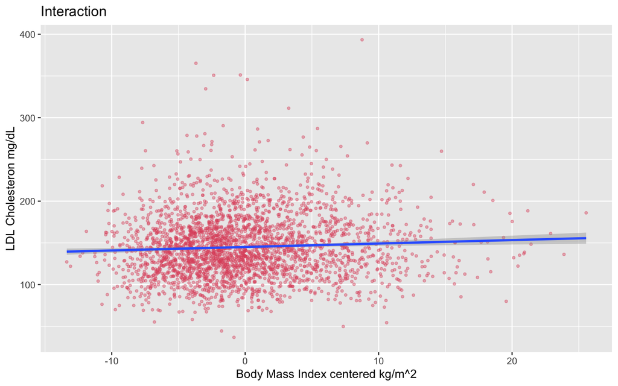

```r
# Comp of regular linear model and robust and some standard error handling
# LDLbmi_model

ggplot(data = hers, mapping = aes(x = BMIc, y = LDL)) +
  labs(x = "Body Mass Index centered kg/m^2",
       y = "LDL Cholesteron mg/dL",
       title = "Interaction") +
  geom_point(shape = 20, color = 2, alpha = 0.4) +
  geom_smooth(method = "lm", formula = y ~ x)
```

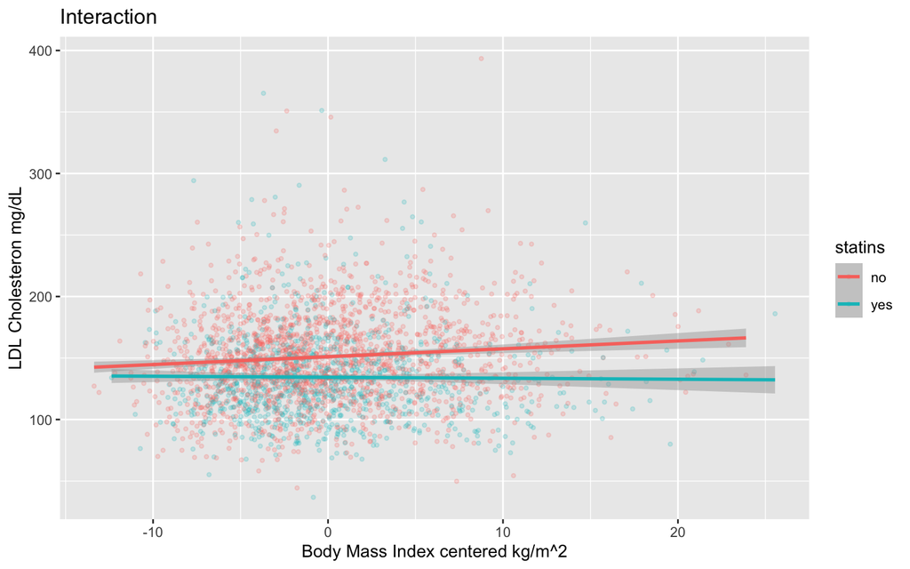

```r
ggplot(data = hers, mapping = aes(x = BMIc, y = LDL, color = statins)) +
  labs(x="Body Mass Index centered kg/m^2",
       y= "LDL Cholesteron mg/dL",
       title = "Interaction") +
  geom_point(shape = 20, alpha = 0.2) +
  geom_smooth(method = "lm", formula = y ~ x)
```

## Interaction and scale

The effect of HT on LDL cholesterol in the HERS trial was dependent on baseline values of LDL, with larger reductions seen among women with higher baseline values. An interaction model for absolute change in LDL from baseline to the first annual visit. Note that baseline LDL is centered in this model in order to make the coefficient for hormone therapy (HT) easier to interpret.  
The coefficients in the model have the following interpretations:

- HT: Among women with the average baseline LDL level of `135mg/dL`, the effect of HT is to lower LDL an average of 15.5mg/dL over the first year of the study.
- cLDL0: Among women assigned to placebo, each mg/dL increase in baseline LDL is associated with a 0.35mg/dL greater decrease in LDL over the first year. That is, women with higher baseline LDL experience greater decreases in the absence of treatment; this is in part due to regression to the mean and in part to greater likelihood of starting use of statins.
- HT * cLDL0: The effect of HT is to lower LDL an additional 0.08mg/dL for each additional mg/dL in baseline LDL. In short, larger treatment effects are seen among women with higher baseline values. The interaction is statistically significant (P = 0:013).

```r
# Results for Table 4.18
# Centered LDL at first visit cLDL0
hers <- mutate(hers, LDLch = LDL1 - LDL)
hers <- mutate(hers, cLDL0 = LDL - mean(LDL, na.rm = TRUE))
LDLch_model <- lm(LDLch ~ HT * cLDL0, data = hers)

summary(LDLch_model)
```

```
##
## Call:
## lm(formula = LDLch ~ HT * cLDL0, data = hers)
##
## Residuals:
##      Min       1Q   Median       3Q      Max
## -158.073  -18.606   -1.568   16.509  241.055
##
## Coefficients:
##                          Estimate Std. Error t value Pr(>|t|)
## (Intercept)              -4.88874    0.84084  -5.814 6.84e-09 ***
## HThormone therapy       -15.47703    1.19625 -12.938  < 2e-16 ***
## cLDL0                    -0.34771    0.02252 -15.442  < 2e-16 ***
## HThormone therapy:cLDL0  -0.07869    0.03164  -2.487   0.0129 *
## ---
## Signif. codes:  0 '***' 0.001 '**' 0.01 '*' 0.05 '.' 0.1 ' ' 1
##
## Residual standard error: 30.48 on 2593 degrees of freedom
##   (166 observations deleted due to missingness)
## Multiple R-squared:  0.2304, Adjusted R-squared:  0.2295
## F-statistic: 258.8 on 3 and 2593 DF,  p-value: < 2.2e-16
```

```r
confint(LDLch_model)
```

```
##                               2.5 %       97.5 %
## (Intercept)              -6.5375232  -3.23995471
## HThormone therapy       -17.8227264 -13.13133982
## cLDL0                    -0.3918593  -0.30355337
## HThormone therapy:cLDL0  -0.1407226  -0.01665171
```

```r
# Percent change Table 4.19
hers <- mutate(hers, LDLpctch = ((LDL1-LDL)/LDL)*100)
LDLpctch_model <- lm(LDLpctch ~ HT * cLDL0, data = hers)

summary(LDLpctch_model)
```

```
##
## Call:
## lm(formula = LDLpctch ~ HT * cLDL0, data = hers)
##
## Residuals:
##     Min      1Q  Median      3Q     Max
## -95.260 -13.855  -1.328  11.266 143.041
##
## Coefficients:
##                          Estimate Std. Error t value Pr(>|t|)
## (Intercept)              -1.28498    0.59847  -2.147   0.0319 *
## HThormone therapy       -10.79035    0.85143 -12.673   <2e-16 ***
## cLDL0                    -0.21624    0.01603 -13.493   <2e-16 ***
## HThormone therapy:cLDL0   0.02188    0.02252   0.972   0.3314
## ---
## Signif. codes:  0 '***' 0.001 '**' 0.01 '*' 0.05 '.' 0.1 ' ' 1
##
## Residual standard error: 21.69 on 2593 degrees of freedom
##   (166 observations deleted due to missingness)
## Multiple R-squared:  0.1606, Adjusted R-squared:  0.1596
## F-statistic: 165.3 on 3 and 2593 DF,  p-value: < 2.2e-16
```

```r
confint(LDLpctch_model)
```

```
##                                2.5 %      97.5 %
## (Intercept)              -2.45850652 -0.11144652
## HThormone therapy       -12.45990543 -9.12078883
## cLDL0                    -0.24766974 -0.18481755
## HThormone therapy:cLDL0  -0.02227728  0.06603073
```

[^1]: All notes are taken from the Regression methods in biostatistics: linear, logistic, survival, and repeated measures models, Chap 4, Vitinghoff et al.